# ARMA Models Lab 2 Extras

This goes into some of the material in Lab 2 in more depth.

```r
load("landings.RData")
landings$log.metric.tons = log(landings$metric.tons)
landings = subset(landings, Year <= 1989)
anchovy = subset(landings, Species=="Anchovy")$log.metric.tons
```

```r
require(urca)
require(ggplot2)
require(tseries)
require(forecast)
require(reshape2)
require(gridExtra)
```

# A random walk

A random walk is non-stationary. The variance increases with time. We can see this is we plot many random walks on top of each other.

A single random walk can be made with a simple for loop or with a `cumsum` on white noise.

```r
# this is a random walk
TT <- 100
sd <- 0.2
rw <- rep(0,TT)
for(i in 2:TT) rw[i] <- rw[i-1]+rnorm(1, sd=sd)
# and this is a random walk
rw <- cumsum(rnorm(TT, sd=sd))
```

Let’s plot 100 random walks on top of each other. Notice how the variance (range of values on the y-axis grows) the farther we get from the start.

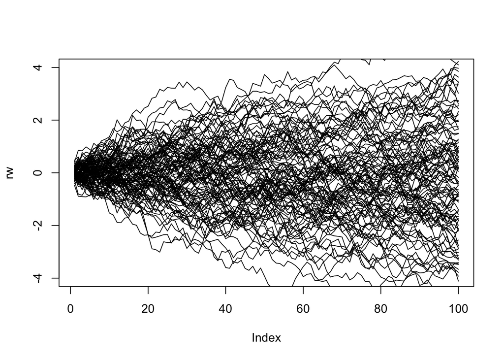

```r
nsim <- 100
plot(rw, type="l", ylim=c(-4,4))
for(i in 1:nsim){
  rw <- cumsum(rnorm(TT, sd=sd))
  lines(rw)
}
```

*Optional* We can make a similar plot with ggplot.

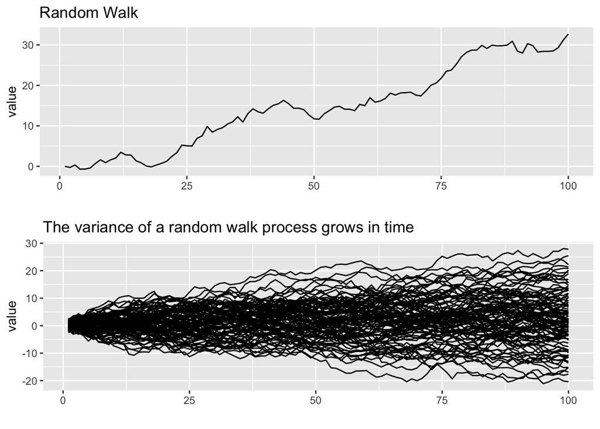

```r
rw <- rep(0,TT)
err <- rnorm(TT, sd)
for(i in 2:TT) rw[i]=rw[i-1]+err[i]
dat <- data.frame(t=1:TT, rw=rw)
p1 <- ggplot(dat, aes(x=t, y=rw)) + geom_line() +
  ggtitle("Random Walk") + xlab("") + ylab("value")
rws <- apply(matrix(rnorm(TT*nsim),TT,nsim),2,cumsum)
rws <- data.frame(rws)
rws$id <- 1:TT

rws2 <- melt(rws, id.var="id")
p2 <- ggplot(rws2, aes(x=id,y=value,group=variable)) +
  geom_line() + xlab("") + ylab("value") +
  ggtitle("The variance of a random walk process grows in time")
grid.arrange(p1, p2, ncol = 1)
```

## *Optional* Adding an intercept to a random walk model

When we add an intercept to a random walk, it behaves very differently than a stationary process with intercept added.

$$x_t = x_{t-1} + \alpha + e_t$$

looks very different than

$$x_t = \beta_1 x_{t-1} + \alpha + e_t$$

Adding an intercept to a random walk leads to an upward linear drift. While in the AR(1) model, it leads to a flat level of $\alpha/(1-\beta_1)$.

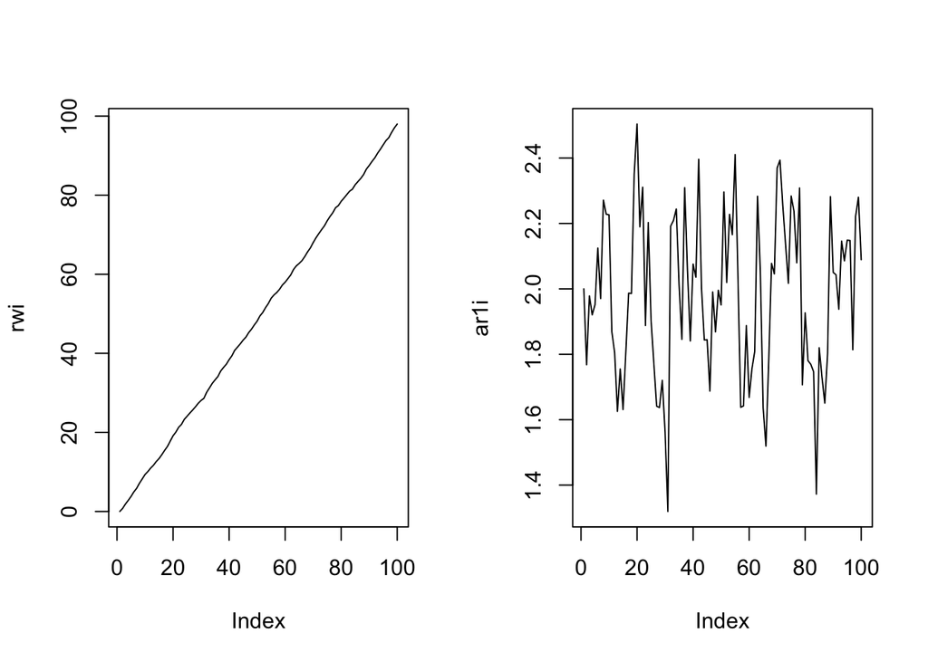

```r
TT <- 100
intercept <- 1
trend <- beta1 <- 0.5
rwi <- rep(0,TT)
err <- rnorm(TT, sd=sd)
for(i in 2:TT) rwi[i] <- rwi[i-1] + intercept + err[i]
ar1i <- rep(intercept/(1-beta1),TT)
for(i in 2:TT) ar1i[i] <- beta1 * ar1i[i-1] + intercept + err[i]
par(mfrow=c(1,2))
plot(rwi, type="l")
plot(ar1i, type="l")
```

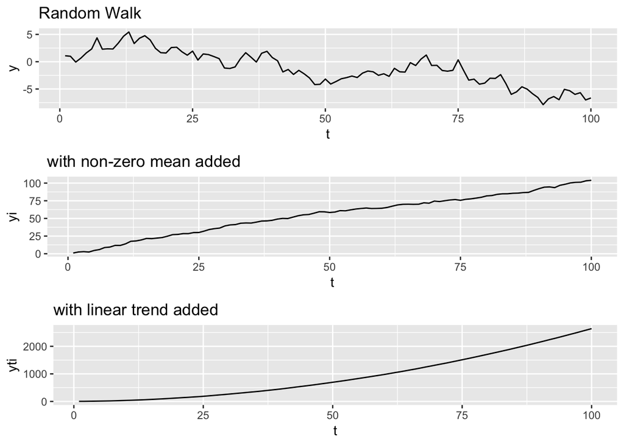

```r
require(ggplot2)
require(gridExtra)
dat <- data.frame(t=1:TT, y=cumsum(rnorm(TT)))
dat$yi <- cumsum(rnorm(TT,intercept,1))
dat$yti <- cumsum(rnorm(TT,intercept+trend*1:TT,1))
p1 <- ggplot(dat, aes(x=t, y=y)) + geom_line() + ggtitle("Random Walk")
p2 <- ggplot(dat, aes(x=t, y=yi)) + geom_line() + ggtitle("with non-zero mean added")
p3 <- ggplot(dat, aes(x=t, y=yti)) + geom_line() + ggtitle("with linear trend added")

grid.arrange(p1, p2, p3, ncol = 1)
```

## Dickey-Fuller test

The null hypothesis for this test is that the data are a random walk (non-stationary). You want the null hypothesis to be rejected.

### Dickey-Fuller test on white noise

Let’s first do the test on data we know is stationary, white noise. We have to make choose the `type` and `lags`. If you have no particular reason to not include an intercept and trend, then use `type="trend"`. This allows both intercept and trend. Next you need to chose the `lags`. The default of `lags=1` is generally ok but we will use `lags=0` to fit a simpler model given that we don’t have many years of data.

It is fitting this model to the data and you are testing if `z.lag.1` is 0.

`x(t) - x(t-1) = z.lag.1 * x(t-1) + intercept + tt * t`

If you see `***` or `**` on the coefficients list for `z.lag.1`, it indicates that `z.lag.1` is significantly different than 0 and this supports the assumption of stationarity.

The `intercept` and `tt` estimates indicate where there is a non-zero level (intercept) or linear trend (tt).

```r
require(urca)
wn <- rnorm(TT)
test <- ur.df(wn, type="trend", lags=0)
summary(test)
```

```
##
## ###############################################
## # Augmented Dickey-Fuller Test Unit Root Test #
## ###############################################
##
## Test regression trend
##
##
## Call:
## lm(formula = z.diff ~ z.lag.1 + 1 + tt)
##
## Residuals:
##      Min       1Q   Median       3Q      Max
## -2.53818 -0.57996 -0.06656  0.72369  2.18661
##
## Coefficients:
##               Estimate Std. Error t value Pr(>|t|)
## (Intercept) -0.0556748  0.2211314  -0.252    0.802
## z.lag.1     -1.2115508  0.1005269 -12.052   <2e-16 ***
## tt           0.0002327  0.0038389   0.061    0.952
## ---
## Signif. codes:  0 '***' 0.001 '**' 0.01 '*' 0.05 '.' 0.1 ' ' 1
##
## Residual standard error: 1.092 on 96 degrees of freedom
## Multiple R-squared:  0.6021, Adjusted R-squared:  0.5938
## F-statistic: 72.63 on 2 and 96 DF,  p-value: < 2.2e-16
##
##
## Value of test-statistic is: -12.052 48.4368 72.6328
##
## Critical values for test statistics:
##       1pct  5pct 10pct
## tau3 -4.04 -3.45 -3.15
## phi2  6.50  4.88  4.16
## phi3  8.73  6.49  5.47
```

The coefficient part of the summary indicates that `z.lag.1` is different than 0 (so stationary) an no support for intercept or trend.

Scroll down and notice that the test statistic is LESS than the critical value for `tau3` at 5 percent. This means the null hypothesis is rejected at $\alpha=0.05$, a standard level for significance testing.

### Dickey-Fuller on the anchovy data

```r
test <- ur.df(anchovy, type="trend", lags=0)
summary(test)
```

```
##
## ###############################################
## # Augmented Dickey-Fuller Test Unit Root Test #
## ###############################################
##
## Test regression trend
##
##
## Call:
## lm(formula = z.diff ~ z.lag.1 + 1 + tt)
##
## Residuals:
##      Min       1Q   Median       3Q      Max
## -0.32439 -0.12677  0.01971  0.13313  0.34676
##
## Coefficients:
##             Estimate Std. Error t value Pr(>|t|)
## (Intercept)  6.09932    1.75245   3.480  0.00212 **
## z.lag.1     -0.72389    0.20947  -3.456  0.00225 **
## tt           0.04171    0.01336   3.123  0.00495 **
## ---
## Signif. codes:  0 '***' 0.001 '**' 0.01 '*' 0.05 '.' 0.1 ' ' 1
##
## Residual standard error: 0.1896 on 22 degrees of freedom
## Multiple R-squared:  0.3522, Adjusted R-squared:  0.2933
## F-statistic: 5.981 on 2 and 22 DF,  p-value: 0.008431
##
##
## Value of test-statistic is: -3.4558 4.3568 5.9805
##
## Critical values for test statistics:
##       1pct  5pct 10pct
## tau3 -4.15 -3.50 -3.18
## phi2  7.02  5.13  4.31
## phi3  9.31  6.73  5.61
```